# Chapter4: Nonparametric Comparison of Survival Distributions

### Comparing two groups of survival times

Testing the equivalence of two groups is a familiar problem in statistics.  
Typically we are interested in testing a **null hypothesis** that two population means are equal versus an **alternative** that the means are not equal (for a two-sided test) or that the mean for an experimental treatment is greater than that for a standard treatment (one-sided test).  
Survival data from biomedical experiments or clinical trials generally doesn’t lend itself to analysis by parametric methods. Thus, we shall construct nonparametric tests of equivalence of two survival functions, $H_0 : S_1(t) = S_0(t)$  
Typically, $S_1$ and $S_0$ will represent the survival distributions for, respectively, an experimental and a control therapy.  
Now, a statistical hypothesis test (in the classical hypothesis testing framework) also requires us to specify an alternative hypothesis, and one might at first try to specify a one-sided alternative $H_A:S_1(t)>S_0(t)$ or two-sided alternative $H_A:S_1(t) \neq S_0(t)$.  
Unfortunately, things aren’t so simple in survival analysis, since the alternative can take a wide range of forms.  
What if the survival distributions are similar for some values of *t* and differ for others?  
What if the survival distributions cross?  
How do we want our test statistic to behave under these different scenarios?  
One solution is to consider what is called a Lehman alternative, $H_A:S_1(t) = [S_0(t)]^{\psi}$.  
Equivalently, we can view Lehman alternatives in terms of proportional hazards as $h_1(t) = \psi h_0(t)$.  
Either way we would construct a one sided test as $H_0:\psi = 1$ versus $H_A:\psi <1$, so that under the alternative hypothesis $S_1(t)$ will be uniformly higher than $S_0(t)$ and $h_1(t)$ uniformly lower than $h_0(t)$ (i.e. subjects in Group 1 will have longer survival times than subjects in Group 0)

### log-rank test

As we shall see, we can construct a test statistic using the ranks of the survival times.  
While these rank-based tests are similar to the Mann-Whitney test, the presence of censoring complicates the assignment of ranks. Thus, we initially take an alternative approach to developing this test, where we view the numbers of failure and numbers at risk at each distinct time as a two-by-two table.

Suppose that the numbers of failures in the control and treatment groups are independent.  
If one then *conditions* on the margins; that is, if one holds $d_i$, $n_i$, $n_{0i}$, and $n_{1i}$ fixed, then the distribution of $d_{0i}$ follows what is known as a hypergeometric distribution.

$$p(d_{0i} | n_{0i}, n_{1i}, d_i) = \frac{\begin{pmatrix}n_{0i}\\d_{0i}\end{pmatrix} \begin{pmatrix}n_{1i}\\d_{1i}\end{pmatrix}}{ \begin{pmatrix}n_i\\d_i\end{pmatrix} }$$
where

$$\begin{pmatrix}n\\d\end{pmatrix} = \frac{n!}{d!(n-d)!}$$
This probability mass function allows one to compute the probability of each possible table with the margins fixed.
The mean and variance are given by

$$e_{0i} = E(d_{0i}) = \frac{n_{0i}d_i}{n_i}$$
where $E(d_{0i})$ is the expected value of $d_{0i}$, and

$$v_{0i} = var(d_{0i}) = \frac{n_{0i} n_{1i} d_i (n_i - d_i)}{n_{i}^2(n_{i} - 1)}$$

We may sum up over all the tables the differences between the observed and expected values to get a linear test statistic $U_0$, and also the sum of the variances $V_0$ as follows, where $D$ is the number of failure times:

$$U_0 = \displaystyle \sum_{i = 1}^{D} (d_{0i} - e_{0i}) = \sum d_{0i} - \sum e_{0i} \\
var(U_0) = \sum v_{0i} = V_0$$
Then we may construct a test statistic that is standard normal,

$$\frac{U_0}{\sqrt V_0} \sim N(0, 1)$$
or equivalently we may use the square of that to get a chi-square random variable with one degree of freedom,

$$\frac{U_0^2}{V_0} \sim \chi^2(df = 1)$$
This test is known as the log-rank test. We illustrate it’s calculation in the following example.

*Example:* Consider a hypothetical comparative clinical trial with six subjects assigned to either a control or treatment group.

```r
(df <- tibble(patient = 1:6,
             survtime = c(6, 7, 10, 15, 19, 25),
             censor = c(1, 0, 1, 1, 0, 1),
             group = c("C", "C", "T", "C", "T", "T")))
```

```
## # A tibble: 6 x 4
##   patient survtime censor group
##     <int>    <dbl>  <dbl> <chr>
## 1       1        6      1 C
## 2       2        7      0 C
## 3       3       10      1 T
## 4       4       15      1 C
## 5       5       19      0 T
## 6       6       25      1 T
```

Since there are four distinct failure times, we may express this data set as a series of four two- by-two tables, where $D$ indicates failure and $\bar{D}$ or “not D”, indicates a non-failure, as shown in Fig

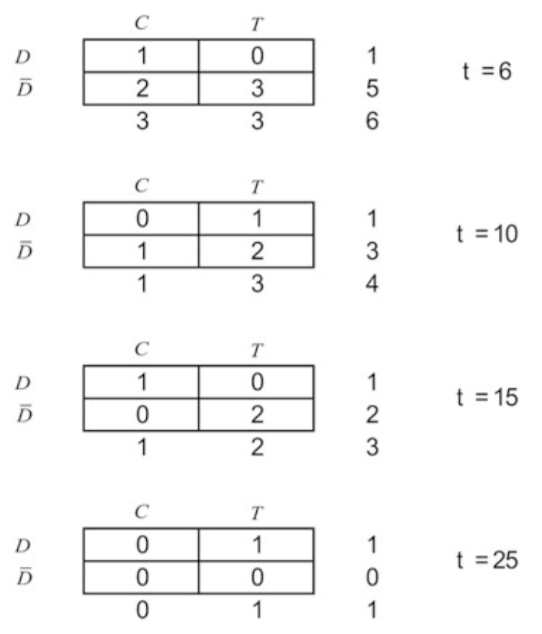

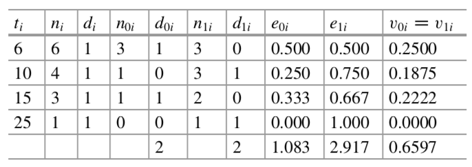

In tabular form, data and calculations of the log-rank test statistic are as follows:  
We have $U_0 = \sum d_{0i} - \sum e_{0i} = 2 - 1.083 = 0.917$, $V_0 = \sum v_{0i} = 0.6597$, and finally the log-rank statistic $X^2 = U_{0}^2 / V_0 = 1.27$, which compare to a chi-square distribution with one degree of freedom.

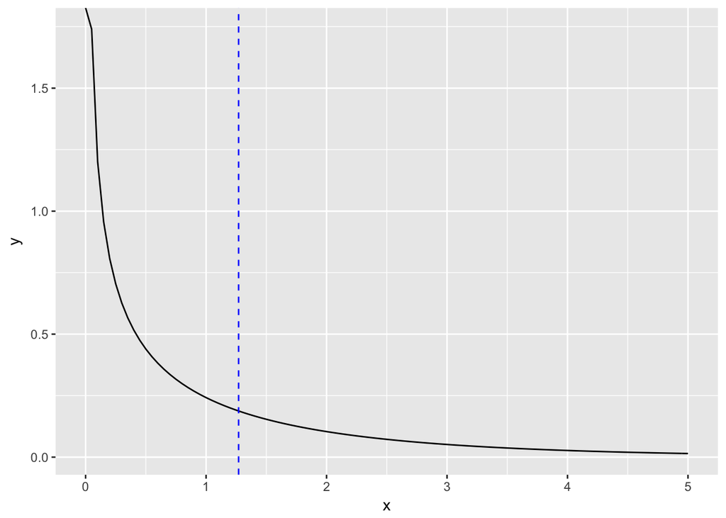

```r
ggplot(tibble(x = 0:5), aes(x = x)) +
  stat_function(fun = dchisq, args = list(df = 1)) +
  geom_vline(xintercept = 1.27, linetype = "dashed", color = "blue")
```

```r
pchisq(1.27, df = 1, lower.tail = FALSE)  # p.value
```

```
## [1] 0.2597667
```

Using the function `survdiff` in the R `survival` package, we obtain the same value of the chi-square statistic (which is rounded to 1.3 in the last row of the output):

```r
survdiff(Surv(survtime, censor) ~ group, data = df)
```

```
## Call:
## survdiff(formula = Surv(survtime, censor) ~ group, data = df)
##
##         N Observed Expected (O-E)^2/E (O-E)^2/V
## group=C 3        2     1.08     0.776      1.27
## group=T 3        2     2.92     0.288      1.27
##
##  Chisq= 1.3  on 1 degrees of freedom, p= 0.3
```

The p-value is 0.259, indicating that the group difference is not statistically significant (which is not surprising due to the extremely small sample size in this illustration).  
Interestingly, the log-rank statistic is identical to a classical test statistic from epidemiology, the Cochran-Mantel-Haenzel test.  
This is a test for independence of two factors (here, treatment and outcome) adjusted for a potential confounder, and is expressed as series of two-by-two tables with a time-stratified confounding factor.  
The log-rank test may also be derived from the proportional hazards model, as we will see in the next chapter.  
An important generalization of this test makes use of a series of $D$ weights $w_i$, with which we may define a weighted log-rank test by

$$U_0(w) = \sum w_i (d_i - e_{0i})$$
and
$$var(U_0) = \sum w_i^2 v_{0i} = V_0(w)$$

The most common way of setting weights is given by the following expression, which uses the product-limit estimator from the combined sample, ignoring group:

$$w_i = \{ \hat{S}(t_i) \}^\rho$$
A log-rank test using these weights is called the **Fleming-Harrington** $G(\rho)$ test.
If $\rho = 0$ this test is equivalent to the log-rank test, since then $w_i = 1$ for all survival times $t_i$.
If $\rho = 1$, we get what is often known as the **Prentice modification** (also known as the **Peto-Peto modification**) of the **Gehan-Wilcoxon test**.

> The **Gehan test**, an adaptation of the Wilcoxon rank-sum test to censored data, is equivalent to a weighted rank test, with weights $w_i = n_i$, that is, each term is weighted by the number of subjects at risk at that time.  
> The **Prentice modification** of the Gehan test uses weights given by $w_i = n\hat{S}(t)$. These weights are similar to those of the Gehan test, but are more stable in small samples.

The effect of this test is then to place higher weight on earlier survival differences. The following example illustrates this.

*Example:* The data set `pancreatic` in the `asaur` package consists of pancreatic cancer data from a Phase II clinical trial where the primary outcome of interest is progression-free survival.  
As we saw in the previous chapter, this quantity is defined as the time from entry into a clinical trial until progression or death, whichever comes first.  
The data consist of, for each patient, the stage, classified as “LA” (locally advanced) or “M” (metastatic), the date of entry into the clinical trial, the date of death (all of the patients in this study died), and the date of progression, if that was observed before death.

```r
head(pancreatic)
```

```
##   stage    onstudy progression      death
## 1     M 12/16/2005    2/2/2006 10/19/2006
## 2     M   1/6/2006   2/26/2006  4/19/2006
## 3    LA   2/3/2006    8/2/2006  1/19/2007
## 4     M  3/30/2006           .  5/11/2006
## 5    LA  4/27/2006   3/11/2007  5/29/2007
## 6     M   5/7/2006   6/25/2006 10/11/2006
```

```r
(pancreatic_tbl <- pancreatic %>%
   tbl_df() %>%
   # change factor to date in "onstudy", "progression" and "death"
   mutate(onstudy = mdy(parse_character(onstudy)),
          progression = mdy(parse_character(progression)),
          death = mdy(parse_character(death))) %>%
   # calculate PFS and OS (months)
   mutate(PFS = parse_number(if_else(!is.na(progression), progression - onstudy, death - onstudy)) / 30,
          OS = parse_number(death - onstudy) / 30)
 )
```

```
## # A tibble: 41 x 6
##    stage onstudy    progression death        PFS    OS
##    <fct> <date>     <date>      <date>     <dbl> <dbl>
##  1 M     2005-12-16 2006-02-02  2006-10-19  1.6  10.2
##  2 M     2006-01-06 2006-02-26  2006-04-19  1.7   3.43
##  3 LA    2006-02-03 2006-08-02  2007-01-19  6    11.7
##  4 M     2006-03-30 NA          2006-05-11  1.4   1.4
##  5 LA    2006-04-27 2007-03-11  2007-05-29 10.6  13.2
##  6 M     2006-05-07 2006-06-25  2006-10-11  1.63  5.23
##  7 LA    2006-08-20 NA          2007-01-24  5.23  5.23
##  8 M     2007-01-22 2007-03-20  2007-04-14  1.9   2.73
##  9 LA    2007-03-02 NA          2008-11-01 20.3  20.3
## 10 M     2007-03-27 NA          2007-05-15  1.63  1.63
## # ... with 31 more rows
```

The log-rank test may be fitted to this data as follows:

```r
# rho = 0, do log-rank test
survdiff(Surv(PFS) ~ stage, rho = 0, data = pancreatic_tbl)
```

```
## Call:
## survdiff(formula = Surv(PFS) ~ stage, data = pancreatic_tbl,
##     rho = 0)
##
##           N Observed Expected (O-E)^2/E (O-E)^2/V
## stage=LA  8        8     12.3      1.49      2.25
## stage=M  33       33     28.7      0.64      2.25
##
##  Chisq= 2.2  on 1 degrees of freedom, p= 0.1
```

Here, the number of patients in each group equals the corresponding observed number of events, since there is no censoring.  
The value of chi-square statistics is 2.2 with 1 degree of freedom, and the p-value is 0.134, which is not statistically significant. Here, we specified that $\rho = 0$. Since this is the default value, it is not necessary.  
If we use the Prentice modification, we must specify that $\rho = 1$:

```r
# rho = 1, Prentice modification
survdiff(Surv(PFS) ~ stage, rho = 1, data = pancreatic_tbl)
```

```
## Call:
## survdiff(formula = Surv(PFS) ~ stage, data = pancreatic_tbl,
##     rho = 1)
##
##           N Observed Expected (O-E)^2/E (O-E)^2/V
## stage=LA  8     2.34     5.88     2.128      4.71
## stage=M  33    18.76    15.22     0.822      4.71
##
##  Chisq= 4.7  on 1 degrees of freedom, p= 0.03
```

We obtain a p-value of 0.0299, which is statistically significant at the 5 % level. What changed is that this version of the test places *higher weight on earlier survival times*.

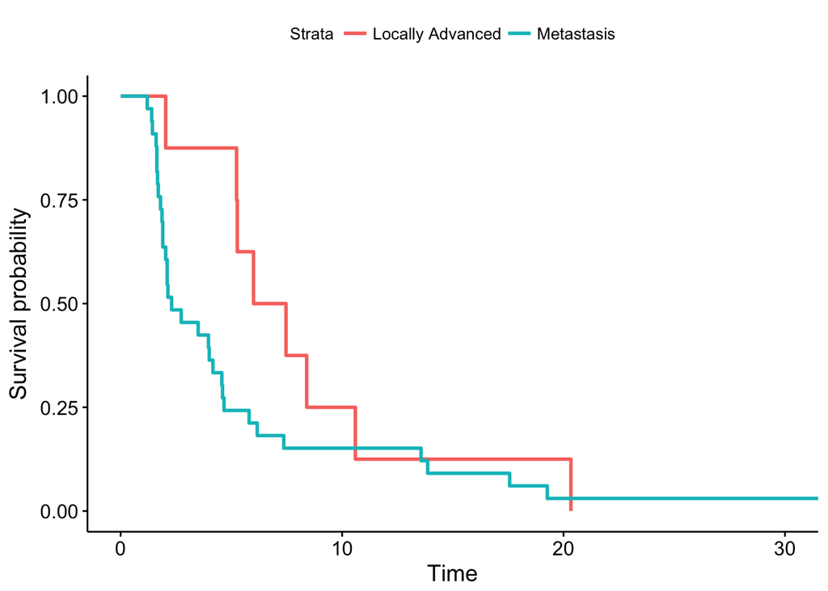

```r
ggsurvplot(survfit(Surv(PFS) ~ stage, data = pancreatic_tbl),
           legend.labs = c("Locally Advanced", "Metastasis"))
```

From this plot, we see that indeed the metastatic group shows an early survival disadvantage over the locally advanced group, but the survival curves converge after about 10 months.  
The reason for the difference is that these two tests, with $\rho = 0$ or $1$, are optimized for different alternatives.  
We will return to this issue when we discuss time dependent covariates and non-proportional hazards.

### Stratified tests

If there is a need to compare two groups while adjusting for another covariate, there are two approaches one can use.  
One is to include the other covariate (or multiple covariates) as regression terms for the hazard function, an approach we will discuss n the next chapter.  
Alternatively, if the covariate we are adjusting for is categorical with a small number of levels $G$, we may construct a **stratified log-rank test**.  
This is a test of the null hypothesis $H_0 : h_{0j}(t) = h_{1j}(t)$ for $j = 1, 2, \cdots, G$.  
Essentially, for each level of the second variable, we compute a score statistic $U_{0g}$ and $V_{0g}$, where $g = 1, 2, \cdots, G$ is the group indicator.  
The test statistic is given by

$$X^2 = \frac{(\sum_{g = 1}^{G} U_{0g})^2}{\sum_{g = 1}^{G} V_{0g}^2} \sim \chi^2(df = 1)$$
which (as for the unstratified log-rank statistic) may be compared to a chi-square distribution with one degree of freedom.
Treatment center, age group, or gender are examples of variables on which we might need to stratify.

*Example:*  
As an example, let us consider the data set `pharmacoSmoking` in the `asaur` package, where the primary goal is to compare the time to relapse (defined in this study as return to smoking) between two treatment groups.  
We may compare the two groups using a log-rank test as follows:

```r
# check "pharmacoSmoking"
head(pharmacoSmoking)
```

```
##    id ttr relapse         grp age gender     race employment yearsSmoking
## 1  21 182       0   patchOnly  36   Male    white         ft           26
## 2 113  14       1   patchOnly  41   Male    white      other           27
## 3  39   5       1 combination  25 Female    white      other           12
## 4  80  16       1 combination  54   Male    white         ft           39
## 5  87   0       1 combination  45   Male    white      other           30
## 6  29 182       0 combination  43   Male hispanic         ft           30
##   levelSmoking ageGroup2 ageGroup4 priorAttempts longestNoSmoke
## 1        heavy     21-49     35-49             0              0
## 2        heavy     21-49     35-49             3             90
## 3        heavy     21-49     21-34             3             21
## 4        heavy       50+     50-64             0              0
## 5        heavy     21-49     35-49             0              0
## 6        heavy     21-49     35-49             2           1825
```

```r
# log-rank test ttr(time to relapse) ~ grp(patchOnly vs combination)
survdiff(Surv(ttr, relapse) ~ grp, data = pharmacoSmoking)
```

```
## Call:
## survdiff(formula = Surv(ttr, relapse) ~ grp, data = pharmacoSmoking)
##
##                  N Observed Expected (O-E)^2/E (O-E)^2/V
## grp=combination 61       37     49.9      3.36      8.03
## grp=patchOnly   64       52     39.1      4.29      8.03
##
##  Chisq= 8  on 1 degrees of freedom, p= 0.005
```

If we are concerned that the group comparison may differ by age, we may define a categorical variable, “ageGroup2”, that divides the subjects into those 49 and under and those 50 and above. We may summarize this variable as follows:

```r
pharmacoSmoking %>%
  group_by(ageGroup2) %>%
  summarise(n = n())
```

```
## # A tibble: 2 x 2
##   ageGroup2     n
##   <fct>     <int>
## 1 21-49        66
## 2 50+          59
```

The variable “ageGroup2” has two levels, with 66 patients in the 21-49 age group and 59 patients 50 years old and older. The log-rank test stratified on “ageGroup2” may be computed as follows:

```r
# stratified log-rank test by "ageGroup2"
survdiff(Surv(ttr, relapse) ~ grp + strata(ageGroup2), data = pharmacoSmoking)
```

```
## Call:
## survdiff(formula = Surv(ttr, relapse) ~ grp + strata(ageGroup2),
##     data = pharmacoSmoking)
##
##                  N Observed Expected (O-E)^2/E (O-E)^2/V
## grp=combination 61       37     49.1      2.99      7.03
## grp=patchOnly   64       52     39.9      3.68      7.03
##
##  Chisq= 7  on 1 degrees of freedom, p= 0.008
```

The chi-square test in this case differs only slightly from the unadjusted value, indicating that it was not necessary to stratify on this variable.  
In the next example we illustrate the impact of a confounder.

*Example:* We shall set up a simulated data set from a clinical trial comparinga standard therapy (control) to an experimental therapy (treated).  
For simplicity, we suppose that the survival times are exponentially distributed, and that the disease is rapidly fatal, so that there is no censoring.  
We also suppose that there is a confounding variable, “genotype”, which can either be wild type (i.e. normal) or mutant, and that patients carrying the mutant genotype have a considerably poorer prognosis.  
Specifically, we set the hazard rate for a mutant patient in the control group at 0.03 per day, and we assume that the effect of treatment is to reduce the hazard by a factor of 0.55.  
We also assume that the hazard rate for wild type patients is reduced by a factor of 0.2 as compared to mutant patients, and that the multiplicative effect of treatment on the wild type patients is the same as for the mutant patients.  
Next, we (1) set a “seed” for the random variable generator, so that this example may be reproduced exactly, (2) generate exponential random variables and string them together into the variable “time”, (3) create the censoring variable “status”, and (4) create the treatment variable “treat” and “genotype” variable, as follows:

```r
# make parameter list
control_mutant <- list(rate = 0.03, rep = 25, treat = "control", genotype = "mutant")
treat_mutant <- list(rate = 0.03 * 0.55, rep = 125, treat = "treat", genotype = "mutant")
control_wild <- list(rate = 0.03 * 0.2, rep = 125, treat = "control", genotype = "wild")
treat_wild <- list(rate = 0.03 * 0.55 * 0.2, rep = 25, treat = "treat", genotype = "wild")

lst <- list(control_mutant, treat_mutant, control_wild, treat_wild)

# set seed
set.seed(4321)

# make simulated df
simulated_df <- map(lst, ~ tibble(time = rexp(.$rep, rate = .$rate),  # survival are exponentially distributed
                                  status = 1,                         # there is no censoring
                                  treat = .$treat,
                                  genotype = .$genotype)) %>%         # making list of tibble
                  bind_rows()                                         # combine dfs

# check the simulated_df
head(simulated_df)
```

```
## # A tibble: 6 x 4
##    time status treat   genotype
##   <dbl>  <dbl> <chr>   <chr>
## 1 34.4       1 control mutant
## 2  1.01      1 control mutant
## 3 17.6       1 control mutant
## 4 16.7       1 control mutant
## 5 20.0       1 control mutant
## 6 10.4       1 control mutant
```

The survival plots comparing the two treatments appears to show that the treatment reduces survival.  
The log-rank test appears to confirm this with a very strong p-value:

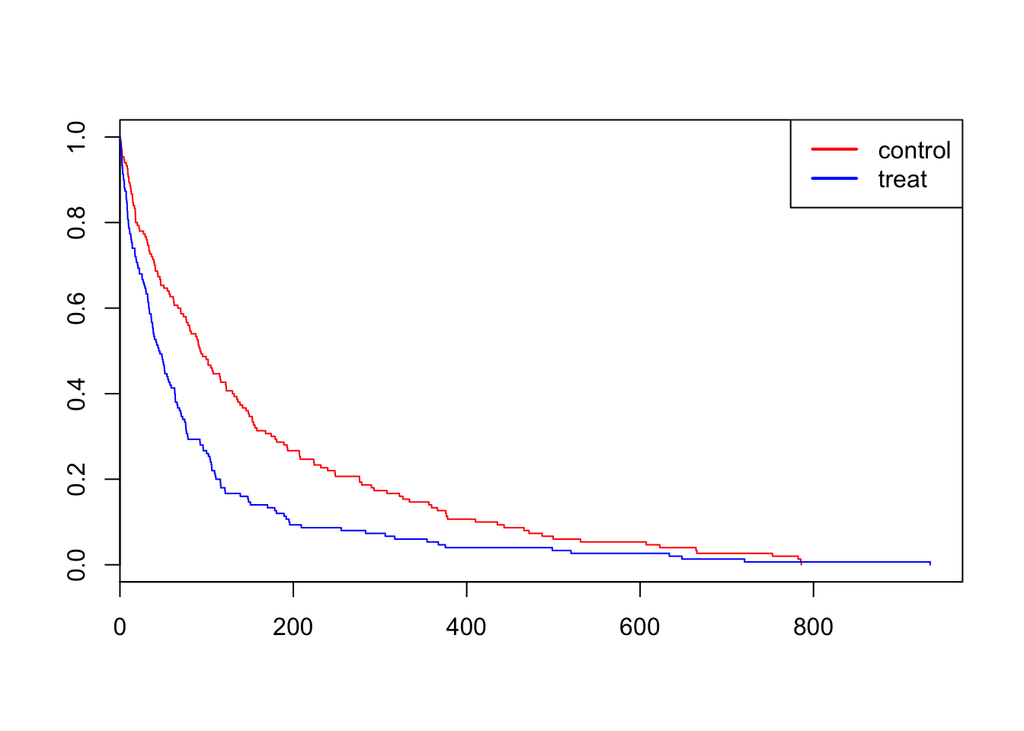

```r
# plot k-m curv
plot(survfit(Surv(time, status) ~ treat, data = simulated_df), col = c("red", "blue"))
legend("topright", legend = c("control", "treat"), col = c("red", "blue"), lwd = 2)
```

```r
# log-rank test
survdiff(Surv(time, status) ~ treat, data = simulated_df)
```

```
## Call:
## survdiff(formula = Surv(time, status) ~ treat, data = simulated_df)
##
##                 N Observed Expected (O-E)^2/E (O-E)^2/V
## treat=control 150      150      183      6.00      15.9
## treat=treat   150      150      117      9.41      15.9
##
##  Chisq= 15.9  on 1 degrees of freedom, p= 7e-05
```

However, when we plot the survival curves comparing treatment to control separately for the mutant and wild type patients, we see that within each genotype the treatment is actually superior to the control.  
We can confirm this using a stratified log-rank test, which shows the difference is highly significant:

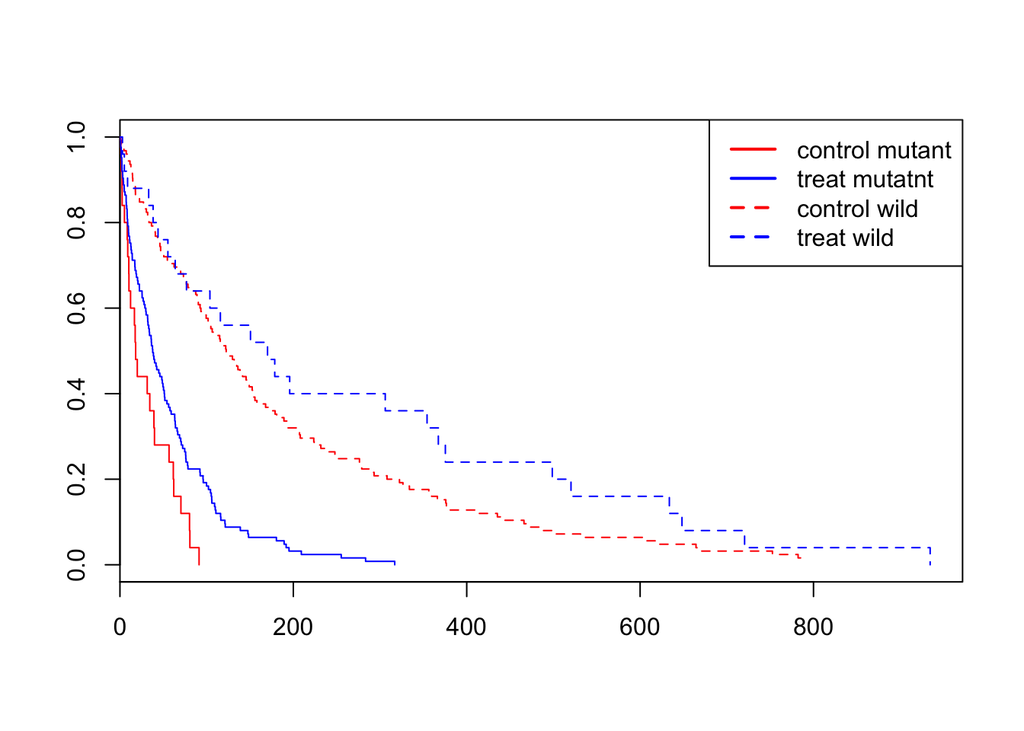

```r
# plot k-m curv stratified by genotype
plot(survfit(Surv(time, status) ~ treat + strata(genotype), data = simulated_df),
     col = c("red", "red", "blue", "blue"), lty = c(1, 2, 1, 2))
legend("topright", legend = c("control mutant", "treat mutatnt", "control wild", "treat wild"),
       col = c("red", "blue", "red", "blue"), lwd = 2, lty = c(1, 1, 2, 2))
```

```r
# log-rank test stratified by genotype
survdiff(Surv(time, status) ~ treat + strata(genotype), data = simulated_df)
```

```
## Call:
## survdiff(formula = Surv(time, status) ~ treat + strata(genotype),
##     data = simulated_df)
##
##                 N Observed Expected (O-E)^2/E (O-E)^2/V
## treat=control 150      150      133      2.17      7.57
## treat=treat   150      150      167      1.73      7.57
##
##  Chisq= 7.6  on 1 degrees of freedom, p= 0.006
```

```r
# there are more mutation-carrying patients in the treatment group than in the control group!
simulated_df %>%
  group_by(treat) %>%
  summarise(mutant = sum(genotype == "mutant"), wild = sum(genotype == "wild"))
```

```
## # A tibble: 2 x 3
##   treat   mutant  wild
##   <chr>    <int> <int>
## 1 control     25   125
## 2 treat      125    25
```

The output from the `survdiff` function does not make it clear which treatment is the superior one, so it is important to also consult the plot to ascertain the directional effect of treatment.  
The explanation for the confounding is that (1) **the treatment improves survival compared to the control**, (2) **patients carrying the wild type form of the gene have better survival than do patients carrying the mutation**, and (3) **there are more mutation-carrying patients in the treatment group than in the control group**, whereas the reverse is true for wild type patients.

Confounding of this type can easily arise in an observational study. For example, the frequency of mutants in one ethnic group may differ significantly from the frequency in the other, and at the same time one of the groups may have had more access to the experimental therapy than did the other.  
If the confounding factor can be observed, then it can be adjusted for, as we have seen.

### Exercise

1. Using the pharmacoSmoking data, compare the two treatments using the Prentice modification of the Gehan test, and compare your results to those from the log-rank test.

```r
# log-rank test
survdiff(Surv(ttr, relapse) ~ grp, data = pharmacoSmoking)
```

```
## Call:
## survdiff(formula = Surv(ttr, relapse) ~ grp, data = pharmacoSmoking)
##
##                  N Observed Expected (O-E)^2/E (O-E)^2/V
## grp=combination 61       37     49.9      3.36      8.03
## grp=patchOnly   64       52     39.1      4.29      8.03
##
##  Chisq= 8  on 1 degrees of freedom, p= 0.005
```

```r
# Using the Prentice modification of Gehan-Wilcoxson test
survdiff(Surv(ttr, relapse) ~ grp, data = pharmacoSmoking, rho = 1)    # It is not great diffrent from log-rank
```

```
## Call:
## survdiff(formula = Surv(ttr, relapse) ~ grp, data = pharmacoSmoking,
##     rho = 1)
##
##                  N Observed Expected (O-E)^2/E (O-E)^2/V
## grp=combination 61     23.1     32.1      2.53      8.01
## grp=patchOnly   64     35.8     26.8      3.04      8.01
##
##  Chisq= 8  on 1 degrees of freedom, p= 0.005
```

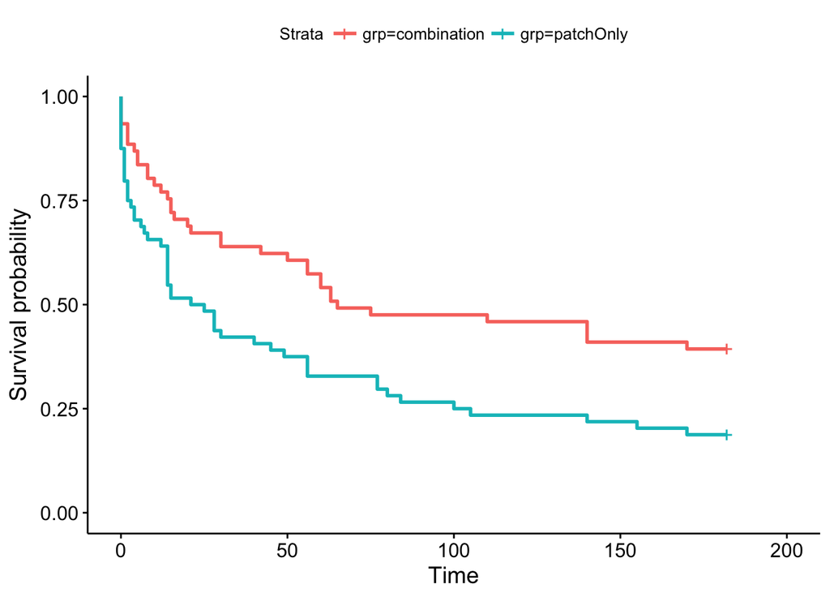

```r
# k-m plot show relapse time has not bias within begging or end of study
ggsurvplot(survfit(Surv(ttr, relapse) ~ grp, data = pharmacoSmoking))
```

2. Again using the pharmacoSmoking data, carry out a log-rank test comparing the two treatments stratifying on employment status.

```r
# log-rank test
survdiff(Surv(ttr, relapse) ~ grp, data = pharmacoSmoking)
```

```
## Call:
## survdiff(formula = Surv(ttr, relapse) ~ grp, data = pharmacoSmoking)
##
##                  N Observed Expected (O-E)^2/E (O-E)^2/V
## grp=combination 61       37     49.9      3.36      8.03
## grp=patchOnly   64       52     39.1      4.29      8.03
##
##  Chisq= 8  on 1 degrees of freedom, p= 0.005
```

```r
# log-rank test stratified by emloyment
survdiff(Surv(ttr, relapse) ~ grp + strata(employment), data = pharmacoSmoking)
```

```
## Call:
## survdiff(formula = Surv(ttr, relapse) ~ grp + strata(employment),
##     data = pharmacoSmoking)
##
##                  N Observed Expected (O-E)^2/E (O-E)^2/V
## grp=combination 61       37     50.3      3.50      8.58
## grp=patchOnly   64       52     38.7      4.54      8.58
##
##  Chisq= 8.6  on 1 degrees of freedom, p= 0.003
```

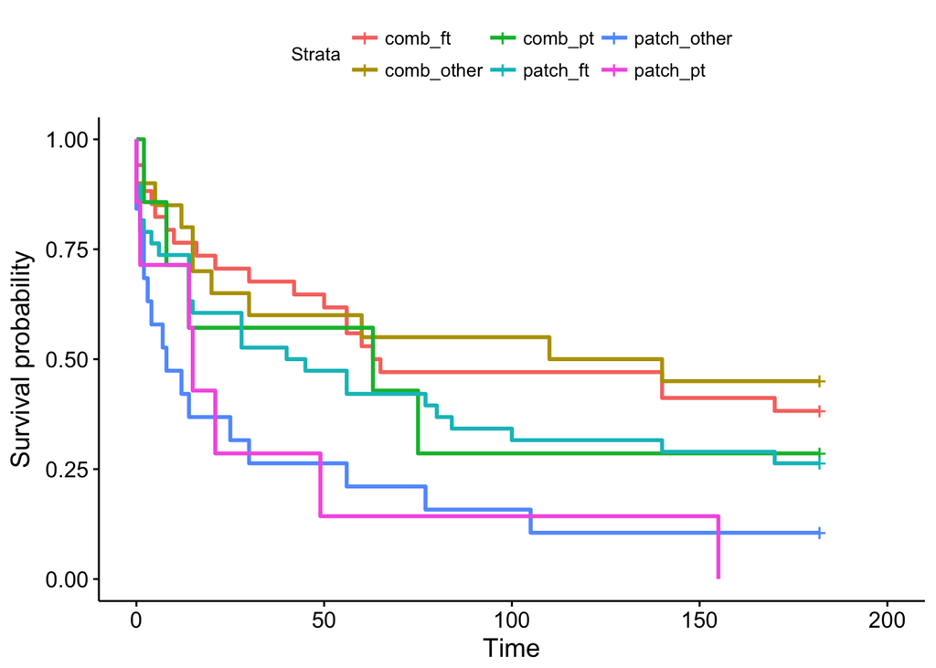

```r
# k-m plot by stratified by employment
survfit(Surv(ttr, relapse) ~ grp + strata(employment), data = pharmacoSmoking) %>%
  ggsurvplot(legend.labs = c("comb_ft", "comb_other", "comb_pt",
                             "patch_ft", "patch_other", "patch_pt"))
```

3. Using the `pancreatic` data set, which has no censored observations, compare the two groups using a Wilcoxon rank-sum test, using the “wilcox.test” function in base R.  
   Compare your results to those from the log-rank and Prentice-modified Gehan tests.

```r
wilcox.test(PFS ~ stage, data = pancreatic_tbl)
```

```
##
##  Wilcoxon rank sum test with continuity correction
##
## data:  PFS by stage
## W = 204.5, p-value = 0.01783
## alternative hypothesis: true location shift is not equal to 0
```

```r
survdiff(Surv(PFS) ~ stage, data = pancreatic_tbl, rho = 1)
```

```
## Call:
## survdiff(formula = Surv(PFS) ~ stage, data = pancreatic_tbl,
##     rho = 1)
##
##           N Observed Expected (O-E)^2/E (O-E)^2/V
## stage=LA  8     2.34     5.88     2.128      4.71
## stage=M  33    18.76    15.22     0.822      4.71
##
##  Chisq= 4.7  on 1 degrees of freedom, p= 0.03
```

4. Again using the `pancreatic` data set, compare the two groups using overall survival as the outcome, using both the log-rank test and the Prentice modification of the Gehan test.  
   Do these two tests yield different results?

```r
# log-rank
survdiff(Surv(OS) ~ stage, data = pancreatic_tbl)
```

```
## Call:
## survdiff(formula = Surv(OS) ~ stage, data = pancreatic_tbl)
##
##           N Observed Expected (O-E)^2/E (O-E)^2/V
## stage=LA  8        8     9.74    0.3093     0.425
## stage=M  33       33    31.26    0.0963     0.425
##
##  Chisq= 0.4  on 1 degrees of freedom, p= 0.5
```

```r
# Gehan-test
survdiff(Surv(OS) ~ stage, data = pancreatic_tbl, rho = 1)
```

```
## Call:
## survdiff(formula = Surv(OS) ~ stage, data = pancreatic_tbl, rho = 1)
##
##           N Observed Expected (O-E)^2/E (O-E)^2/V
## stage=LA  8     3.32      4.9     0.513      1.02
## stage=M  33    17.73     16.1     0.156      1.02
##
##  Chisq= 1  on 1 degrees of freedom, p= 0.3
```

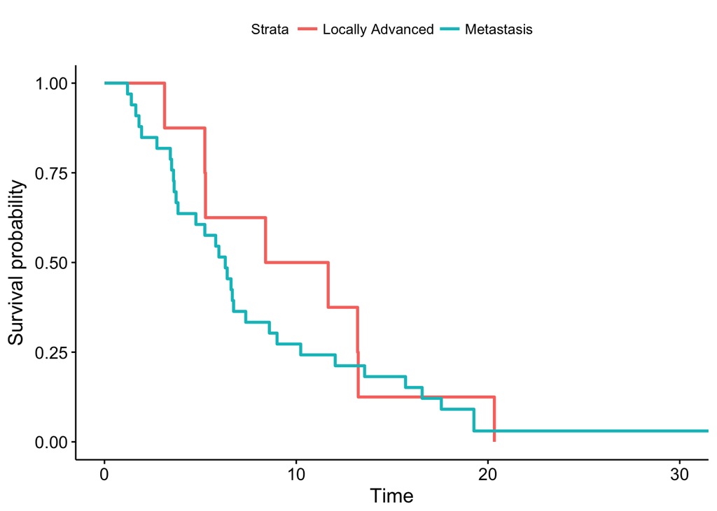

```r
# k-m plot
survfit(Surv(OS) ~ stage, data = pancreatic_tbl) %>%
  ggsurvplot(legend.labs = c("Locally Advanced", "Metastasis"))
```